HUIJZER.XYZ

# Random forest classification in Julia

2021-01-21

Below is example code for fitting and evaluating a linear regression and random forest classifier in Julia. I've used both models to have a baseline for the random forest. The model is evaluated on a mock variable $U$ generated from two distributions, namely

$$\begin{aligned}
d_1 &= \text{Normal}(\mu_1, \sigma) \: \: \text{and} \\
d_2 &= \text{Normal}(\mu_2, \sigma),
\end{aligned}$$

where $\mu_1 = 10$, $\mu_2 = 12$ and $\sigma = 2$. The random variable $V$ is just noise meant to fool the classifier.

This data isn't meant to show that random forests are good classifiers. One way to do that would be to have more variables than observations (Biau & Scornet, 2016).

# Data generation

```julia
begin
	import MLDataUtils
	import MLJGLMInterface
	import MLJDecisionTreeInterface

	using AlgebraOfGraphics
	using CairoMakie
	using CategoricalArrays
	using DataFrames
	using Distributions
	using MLJBase
	using MLJ
	using StableRNGs: StableRNG
	using Random
end
```

```julia
df = let
	n = 80
	μ1 = 10
	μ2 = 12
	σ = 2

	d1 = Normal(μ1, σ)
	d2 = Normal(μ2, σ)

	Random.seed!(123)
	classes = categorical(rand(["A", "B"], n))

	df = DataFrame(
		class = categorical(classes),
		U = [class == "A" ? rand(d1) : rand(d2) for class in classes],
		V = rand(Normal(100, 10), n)
	)
end
```

| class | U | V |
| --- | --- | --- |
| CategoricalValue{String, UInt32} "B" | 11.5802 | 111.588 |
| CategoricalValue{String, UInt32} "A" | 10.0062 | 99.9623 |
| CategoricalValue{String, UInt32} "A" | 12.719 | 93.8876 |
| CategoricalValue{String, UInt32} "A" | 10.6082 | 110.054 |
| CategoricalValue{String, UInt32} "B" | 8.8399 | 108.481 |
| CategoricalValue{String, UInt32} "B" | 13.2351 | 99.2827 |
| CategoricalValue{String, UInt32} "A" | 9.97171 | 90.8848 |
| CategoricalValue{String, UInt32} "B" | 8.75458 | 113.906 |
| CategoricalValue{String, UInt32} "A" | 8.96639 | 89.2201 |
| CategoricalValue{String, UInt32} "B" | 10.3287 | 113.208 |
| ... |  |  |
| CategoricalValue{String, UInt32} "A" | 12.0734 | 101.862 |

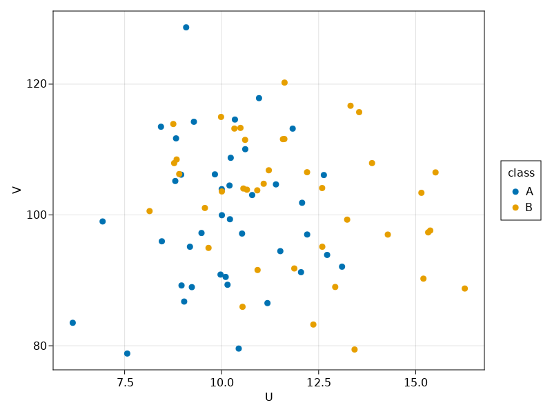

```julia
let
	uv = data(df) * mapping(:U, :V, color=:class)
	draw(uv)
end
```

# Train and test split

Training and evaluating (testing) on the same data is not particulary useful because we want to know how well our model generalizes. For more information, see topics such as [overfitting](https://en.wikipedia.org/wiki/Overfitting). Instead, we split the data up in a train and test set.

```julia
train, test = let
	rng = StableRNG(123)
	MLJ.partition(eachindex(df.class), 0.7; shuffle=true, rng)
end;
```

# Model fitting

```julia
logistic_model = let
	LinearBinary = @load LinearBinaryClassifier pkg=GLM verbosity=0
	logistic_model = LinearBinary()
end;
```

```julia
begin
	logistic = machine(logistic_model, (U = df.U, V = df.V), df.class)
	fit!(logistic; rows=train)
	fitted_params(logistic).coef
end
```

```
[0.717045, 0.0409366, -12.2757]
```

The second coefficient in the linear model is close to zero. This is exactly what the model should do since `V` is random noise.

```julia
forest_model = let
	DecisionTree = @load DecisionTreeClassifier pkg=DecisionTree verbosity=0
	tree = DecisionTree()
	EnsembleModel(atom=tree, n=10)
end;
```

```julia
forest = let
	forest = machine(forest_model, (U = df.U, V = df.V), df.class)
	fit!(forest; rows=train);
	forest
end;
```

# Accuracy

Now that we have fitted the two models, we can compare the accuracies and plot the [receiver operating characteristic](https://en.wikipedia.org/wiki/Receiver_operating_characteristic).

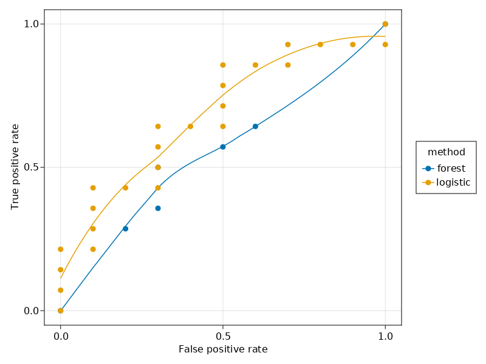

```julia
let
	truths = df.class[test]

	logistic_predictions = MLJ.predict(logistic, rows=test)
	logistic_fprs, logistic_tprs, _ = roc_curve(logistic_predictions, truths)

	forest_predictions = MLJ.predict(forest, rows=test)
	forest_fprs, forest_tprs, _ = roc_curve(forest_predictions, truths)

	logistic_df = DataFrame(
		x = logistic_fprs,
		y = logistic_tprs,
		method = "logistic"
	)

	forest_df = DataFrame(
		x = forest_fprs,
		y = forest_tprs,
		method = "forest"
	)

	roc_df = vcat(logistic_df, forest_df)

	xy = data(roc_df)
	xy *= smooth() + visual(Scatter)
	xy *= mapping(
		:x => "False positive rate",
		:y => "True positive rate",
		color=:method)

	draw(xy)
end
```

# K-fold cross-validation

By doing a train and test split, we basically threw a part of the data away. For small datasets, like the dataset in this example, that is not very efficient. Therefore, we also do a k-fold cross-validation.

```julia
folds = let
	Random.seed!(123)
	rng = MersenneTwister(123)
	indexes = shuffle(rng, eachindex(df.class))
	folds = MLDataUtils.kfolds(indexes, k = 8)
end;
```

```julia
r3(x) = round(x; digits=3);
```

```julia
function fitted_accuracy(model, train, test)
    forest = machine(model, (U = df.U, V = df.V), df.class)
    fit!(forest; rows=train)
    predictions = predict_mode(forest, rows=test)
    return accuracy(predictions, df.class[test]) |> r3
end;
```

```julia
let
	accuracies = [fitted_accuracy(logistic_model, train, test) for (train, test) in folds]
	accuracies, mean(accuracies) |> r3
end
```

```
([0.7, 0.7, 0.4, 0.6, 0.7, 0.8, 0.7, 0.6], 0.65)
```

```julia
let
	accuracies = [fitted_accuracy(forest_model, train, test) for (train, test) in folds]
	accuracies, mean(accuracies) |> r3
end
```

```
([0.5, 0.6, 0.3, 0.5, 0.5, 0.7, 0.5, 0.4], 0.5)
```

*This blog post was built via a Pluto.jl notebook*.

## References

Biau, G., Scornet, E. (2016). A Random Forest Guided Tour. TEST 25, 197–227 (2016). https://doi.org/10.1007/s11749-016-0481-7

[CC BY-SA 4.0](http://creativecommons.org/licenses/by-sa/4.0/) Rik Huijzer. Website built with Franklin.jl and the [Julia programming language](https://julialang.org). Last update: 2021-11-07.